# HW4

Max Moro

September 19, 2018

**Setup Libraries**

```r
knitr::opts_chunk$set(echo = TRUE)
library(rvest)
```

```r
library(ggplot2)
library(scales)
library(tidyverse)
library(ggthemes)
#https://blog.rstudio.com/2014/11/24/rvest-easy-web-scraping-with-r/
```

# Question 1 - Harry Potter

**Harry Potter Cast (50%)**

## 1a.

In the IMDB, there are listings of full cast members for movies. Navigate to http://www.imdb.com/title/tt1201607/fullcredits?ref_=tt_ql_1. Feel free to View Source to get a good idea of what the page looks like in code.

- Used **SelectorGadget** to analyze the page
- Found that I need the node **.even td , .odd td**

## 1b.

Scrape the page with any R package that makes things easy for you. Of particular interest is the table of the Cast in order of crediting. Please scrape this table (you might have to fish it out of several of the tables from the page) and make it a data.frame() of the Cast in your R environment

- Used **rvest** package, see code at 1c

## 1c.

Clean Up the Table

• It should not have blank observations or rows, a row that should be column names, or just ‘…’

• It should have intuitive column names (ideally 2 to start – Actor and Character)

• In the film, Mr. Warwick plays two characters, which makes his row look a little weird. Please replace his character column with just “Griphook / Professor Filius Flitwick” to make it look better.

• One row might result in “Rest of cast listed alphabetically” – remove this observation.

- This is the **full code** from 1a to 1c.

```r
HP = read_html('https://www.imdb.com/title/tt1201607/fullcredits')

dataHP= HP %>%
  #getting the HTML note
  html_nodes('.even td , .odd td')    %>%
  #converting to text
  html_text(T)  %>%
  #creating a matrix and dataframe
  matrix(ncol=4,byrow=T) %>%
  data.frame(stringsAsFactors = F) %>%
  #keepping only the actor and character col
  dplyr::select(X2,X4) %>%
  #Renaming
  rename(Actor=X2,Character=X4) %>%
  #remove all \n
  mutate(Character = gsub("\n"," ",Character,fixed=T))


head(dataHP)
```

```
##              Actor                  Character
## 1    Ralph Fiennes             Lord Voldemort
## 2   Michael Gambon Professor Albus Dumbledore
## 3     Alan Rickman    Professor Severus Snape
## 4 Daniel Radcliffe               Harry Potter
## 5     Rupert Grint                Ron Weasley
## 6      Emma Watson           Hermione Granger
```

```r
#Mr. Warwick is alrady clean in the source HTML (I think the page has been change#)
message("Duplicated Actors (multiple roles): ",sum(duplicated(dataHP$Actor)))
```

```
## Duplicated Actors (multiple roles): 0
```

```r
message("Any Row with 'Rest of cast'?: ",sum(grepl('^Rest of cast',dataHP$Actor)))
```

```
## Any Row with 'Rest of cast'?: 0
```

## 1d.

Split the Actor’s name into two columns: FirstName and Surname. Keep in mind that some actors/actresses have middle names as well. Please make sure that the middle names are in the FirstName column, in addition to the first name (example: given the Actor Frank Jeffrey Stevenson, the FirstName column would say “Frank Jeffrey.”)

```r
dataHP = dataHP %>%
  separate(Actor,c('FirstName','Surname'),sep=' (?=[^ ]+$)',keep=TRUE)

head(dataHP)
```

```
##   FirstName   Surname                  Character
## 1     Ralph   Fiennes             Lord Voldemort
## 2   Michael    Gambon Professor Albus Dumbledore
## 3      Alan   Rickman    Professor Severus Snape
## 4    Daniel Radcliffe               Harry Potter
## 5    Rupert     Grint                Ron Weasley
## 6      Emma    Watson           Hermione Granger
```

## 1e.

Present the first 10 rows of the data.frame() – It should have only FirstName, Surname, and Character columns.

```r
head(dataHP,10)
```

```
##    FirstName   Surname                                          Character
## 1      Ralph   Fiennes                                     Lord Voldemort
## 2    Michael    Gambon                         Professor Albus Dumbledore
## 3       Alan   Rickman                            Professor Severus Snape
## 4     Daniel Radcliffe                                       Harry Potter
## 5     Rupert     Grint                                        Ron Weasley
## 6       Emma    Watson                                   Hermione Granger
## 7     Evanna     Lynch                                      Luna Lovegood
## 8   Domhnall   Gleeson                                       Bill Weasley
## 9   Clémence     Poésy                                     Fleur Delacour
## 10   Warwick     Davis Griphook /               Professor Filius Flitwick
```

```r
DT::datatable(dataHP)
```

|  | FirstName | Surname | Character |
| --- | --- | --- | --- |
| 1 | Ralph | Fiennes | Lord Voldemort |
| 2 | Michael | Gambon | Professor Albus Dumbledore |
| 3 | Alan | Rickman | Professor Severus Snape |
| 4 | Daniel | Radcliffe | Harry Potter |
| 5 | Rupert | Grint | Ron Weasley |
| 6 | Emma | Watson | Hermione Granger |
| 7 | Evanna | Lynch | Luna Lovegood |
| 8 | Domhnall | Gleeson | Bill Weasley |
| 9 | Clémence | Poésy | Fleur Delacour |
| 10 | Warwick | Davis | Griphook / Professor Filius Flitwick |

[output cut: 144 more lines]

*data from [IMDB](https://www.imdb.com/title/tt1201607/fullcredits)*

# Question 2- SportsBall

**SportsBall (50%)**

## 2a.

1. On the ESPN website, there are statistics of each NBA player. Navigate to the San Antonio Spurs current statistics (likely http://www.espn.com/nba/team/stats/_/name/sa/san-antonio-spurs). You are interested in the Shooting Statistics table.
- Using **html_table** function in **rvest** library to gather the second table (shooting statistics)

## 2b.

Scrape the page with any R package that makes things easy for you. There are a few tables on the page, so make sure you are targeting specifically the Shooting Statistics table.

```r
#reading the HTML
SB = read_html('http://www.espn.com/nba/team/stats/_/name/sa/san-antonio-spurs')
#getting the second table
SBShooting = html_table(SB,fill=T,header=T)[[2]]
#convert to dataframe (first rows has the col names)
SBtable = data.frame(SBShooting[-1,])
#set col names
names(SBtable)= SBShooting[1,]
head(SBtable)
```

```
##                  PLAYER FGM  FGA  FG% 3PM 3PA  3P% FTM FTA  FT% 2PM  2PA
## 2 LaMarcus Aldridge, PF 7.4 16.0 .463 0.6 1.0 .600 8.2 8.4 0.98 6.8 15.0
## 3       Patty Mills, PG 5.0 11.4 .439 2.6 7.0 .371 0.8 1.0 0.80 2.4  4.4
## 4          Rudy Gay, SF 5.2 13.0 .400 0.8 3.6 .222 1.0 1.8 0.56 4.4  9.4
## 5      Manu Ginobili, G 3.0  7.4 .405 1.2 3.6 .333 1.8 2.2 0.82 1.8  3.8
## 6   Dejounte Murray, PG 2.8  6.2 .452 0.8 1.2 .667 1.4 1.8 0.78 2.0  5.0
## 7       Tony Parker, PG 2.8  7.4 .378 0.0 1.0 .000 1.0 1.4 0.71 2.8  6.4
##    2P%   PPS AFG%
## 2 .453 1.475 0.48
## 3 .545 1.175 0.55
## 4 .468  .938 0.43
## 5 .474 1.216 0.49
## 6 .400 1.258 0.52
## 7 .438  .892 0.38
```

## 2c.

Clean up the table (You might get some warnings if you’re working with tibbles)

- You’ll want to create an R data.frame() with one observation for each player. Make sure that you do not accidentally include blank rows, a row of column names, or the Totals row in the table as observations.

```r
SBtable = SBtable %>%
  #removing Totals
  filter(PLAYER != 'Totals') %>%
  #convert to numeric
  mutate_at(names(SBtable)[-1],as.numeric)

head(SBtable)
```

```
##                  PLAYER FGM  FGA   FG% 3PM 3PA   3P% FTM FTA  FT% 2PM  2PA
## 1 LaMarcus Aldridge, PF 7.4 16.0 0.463 0.6 1.0 0.600 8.2 8.4 0.98 6.8 15.0
## 2       Patty Mills, PG 5.0 11.4 0.439 2.6 7.0 0.371 0.8 1.0 0.80 2.4  4.4
## 3          Rudy Gay, SF 5.2 13.0 0.400 0.8 3.6 0.222 1.0 1.8 0.56 4.4  9.4
## 4      Manu Ginobili, G 3.0  7.4 0.405 1.2 3.6 0.333 1.8 2.2 0.82 1.8  3.8
## 5   Dejounte Murray, PG 2.8  6.2 0.452 0.8 1.2 0.667 1.4 1.8 0.78 2.0  5.0
## 6       Tony Parker, PG 2.8  7.4 0.378 0.0 1.0 0.000 1.0 1.4 0.71 2.8  6.4
##     2P%   PPS AFG%
## 1 0.453 1.475 0.48
## 2 0.545 1.175 0.55
## 3 0.468 0.938 0.43
## 4 0.474 1.216 0.49
## 5 0.400 1.258 0.52
## 6 0.438 0.892 0.38
```

```r
tail(SBtable)
```

```
##                  PLAYER FGM FGA   FG% 3PM 3PA   3P% FTM FTA  FT% 2PM 2PA
## 9       Bryn Forbes, SG 1.3 4.3 0.294 0.5 2.3 0.222 1.3 1.8 0.71 0.8 2.0
## 10      Danny Green, SG 1.6 6.0 0.267 1.0 4.0 0.250 0.0 0.0 0.00 0.6 2.0
## 11     Davis Bertans, C 0.6 3.6 0.167 0.6 3.2 0.188 1.6 2.2 0.73 0.0 0.4
## 12    Derrick White, PG 1.0 2.0 0.500 0.3 0.7 0.500 0.0 0.0 0.00 0.7 1.3
## 13 Joffrey Lauvergne, C 1.0 1.0 1.000 0.0 0.0 0.000 0.0 0.0 0.00 1.0 1.0
## 14      Brandon Paul, G 0.0 0.0 0.000 0.0 0.0 0.000 0.0 0.0 0.00 0.0 0.0
##      2P%   PPS AFG%
## 9  0.375 1.000 0.35
## 10 0.300 0.700 0.35
## 11 0.000 0.944 0.25
## 12 0.500 1.167 0.58
## 13 1.000 2.000 1.00
## 14 0.000 0.000 0.00
```

- The column PLAYER has two variables of interest in it: the player’s name and their position, denoted by 1-2 letters after their name. Split the cells into two columns, one with Name and the other Position.

```r
SBtable = SBtable %>%
  separate(PLAYER,c('Name','Position'),sep=', ')

DT::datatable(SBtable)
```

|  | Name | Position | FGM | FGA | FG% | 3PM | 3PA | 3P% | FTM | FTA | FT% | 2PM | 2PA | 2P% | PPS | AFG% |
| --- | --- | --- | --- | --- | --- | --- | --- | --- | --- | --- | --- | --- | --- | --- | --- | --- |
| 1 | LaMarcus Aldridge | PF | 7.4 | 16 | 0.463 | 0.6 | 1 | 0.6 | 8.2 | 8.4 | 0.98 | 6.8 | 15 | 0.453 | 1.475 | 0.48 |
| 2 | Patty Mills | PG | 5 | 11.4 | 0.439 | 2.6 | 7 | 0.371 | 0.8 | 1 | 0.8 | 2.4 | 4.4 | 0.545 | 1.175 | 0.55 |
| 3 | Rudy Gay | SF | 5.2 | 13 | 0.4 | 0.8 | 3.6 | 0.222 | 1 | 1.8 | 0.56 | 4.4 | 9.4 | 0.468 | 0.938 | 0.43 |
| 4 | Manu Ginobili | G | 3 | 7.4 | 0.405 | 1.2 | 3.6 | 0.333 | 1.8 | 2.2 | 0.82 | 1.8 | 3.8 | 0.474 | 1.216 | 0.49 |
| 5 | Dejounte Murray | PG | 2.8 | 6.2 | 0.452 | 0.8 | 1.2 | 0.667 | 1.4 | 1.8 | 0.78 | 2 | 5 | 0.4 | 1.258 | 0.52 |
| 6 | Tony Parker | PG | 2.8 | 7.4 | 0.378 | 0 | 1 | 0 | 1 | 1.4 | 0.71 | 2.8 | 6.4 | 0.438 | 0.892 | 0.38 |
| 7 | Pau Gasol | C | 2 | 4 | 0.5 | 0.2 | 0.6 | 0.333 | 1.8 | 2 | 0.9 | 1.8 | 3.4 | 0.529 | 1.5 | 0.53 |
| 8 | Kyle Anderson | SF | 2.4 | 4 | 0.6 | 0 | 0.8 | 0 | 0.6 | 0.8 | 0.75 | 2.4 | 3.2 | 0.75 | 1.35 | 0.6 |
| 9 | Bryn Forbes | SG | 1.3 | 4.3 | 0.294 | 0.5 | 2.3 | 0.222 | 1.3 | 1.8 | 0.71 | 0.8 | 2 | 0.375 | 1 | 0.35 |
| 10 | Danny Green | SG | 1.6 | 6 | 0.267 | 1 | 4 | 0.25 | 0 | 0 | 0 | 0.6 | 2 | 0.3 | 0.7 | 0.35 |

[output cut: 4 more lines]

- Check the data type of all columns. Convert relevant columns to numeric. Check the data type of all columns again to confirm that they have changed!

- **done in step 2c**

```r
str(SBtable)
```

```
## 'data.frame':    14 obs. of  16 variables:
##  $ Name    : chr  "LaMarcus Aldridge" "Patty Mills" "Rudy Gay" "Manu Ginobili" ...
##  $ Position: chr  "PF" "PG" "SF" "G" ...
##  $ FGM     : num  7.4 5 5.2 3 2.8 2.8 2 2.4 1.3 1.6 ...
##  $ FGA     : num  16 11.4 13 7.4 6.2 7.4 4 4 4.3 6 ...
##  $ FG%     : num  0.463 0.439 0.4 0.405 0.452 0.378 0.5 0.6 0.294 0.267 ...
##  $ 3PM     : num  0.6 2.6 0.8 1.2 0.8 0 0.2 0 0.5 1 ...
##  $ 3PA     : num  1 7 3.6 3.6 1.2 1 0.6 0.8 2.3 4 ...
##  $ 3P%     : num  0.6 0.371 0.222 0.333 0.667 0 0.333 0 0.222 0.25 ...
##  $ FTM     : num  8.2 0.8 1 1.8 1.4 1 1.8 0.6 1.3 0 ...
##  $ FTA     : num  8.4 1 1.8 2.2 1.8 1.4 2 0.8 1.8 0 ...
##  $ FT%     : num  0.98 0.8 0.56 0.82 0.78 0.71 0.9 0.75 0.71 0 ...
##  $ 2PM     : num  6.8 2.4 4.4 1.8 2 2.8 1.8 2.4 0.8 0.6 ...
##  $ 2PA     : num  15 4.4 9.4 3.8 5 6.4 3.4 3.2 2 2 ...
##  $ 2P%     : num  0.453 0.545 0.468 0.474 0.4 0.438 0.529 0.75 0.375 0.3 ...
##  $ PPS     : num  1.475 1.175 0.938 1.216 1.258 ...
##  $ AFG%    : num  0.48 0.55 0.43 0.49 0.52 0.38 0.53 0.6 0.35 0.35 ...
```

## 2d.

Create a colorful bar chart that shows the Field Goals Percentage Per Game for each person. It will be graded on the following criteria

• Informative Title, centered

• Relevant x and y axis labels (not simply variables names!)

• Human-readable axes with no overlap (you might have to flip x and y to fix that). Note: You do not have to convert the decimal to a percentage.

• Color the columns by the team member’s position (so, all PF’s should have the same color, etc.)

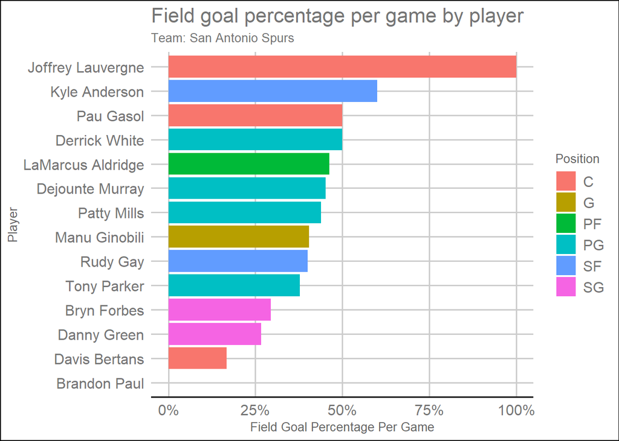

```r
SBtable$Name = forcats::fct_reorder(SBtable$Name,SBtable$`FG%`)
ggplot(data=SBtable
       ,aes(x=Name,y=`FG%`,fill=Position)) +
       #,aes(x=reorder(Name,`FG%`),y=`FG%`,fill=Position)) + # also works without the forcats
  geom_col() +
  coord_flip() +
  ggplot2::ggtitle('Field goal percentage per game by player',subtitle='Team: San Antonio Spurs') +
  ggthemes::theme_gdocs() +
  ggplot2::scale_y_continuous(labels=percent,name='Field Goal Percentage Per Game') +
  xlab('Player') +
  ggplot2::theme(title=element_text(size=10,hjust=))
```

*data from [ESPN](http://www.espn.com/nba/team/stats/_/name/sa/san-antonio-spurs)*